# Technical Applications & Data Analytics (WS 2021)

## Einführung und Erarbeitung der „Data Management“

- Grundlagen der Algorithmen
- Data Management Methoden
- Prozesse des Data Mining
- Techniken des Data Mining
- Visuelle und Maschinelle Verfahren des Data Mining
- Einführung und Übersicht der Algorithmen des Data Mining
- Interpretation der Verschiedenen Algorithmen und Reflektion der Ergebnisse des Data Mining
- Grundlagen des Web und Text Mining

### 3.a) Grundlagen der Algorithmen

#### Definition Algorithmus

*Ein **Algorithmus** ist eine formale Handlungsvorschrift zur Lösung von Instanzen einer bestimmten Problemklasse.* (Sauer, 2019)

Die Bezeichnung ist abgeleitet aus dem Namen des persischen Gelehrten Muhammad ibn Musa al-Chwarizmi.

#### Informelle Beispiele

In der Alltagssprache werden oft informelle Beispiele für Algorithmen angeführt, z. B.:

- Kochrezept
- Bauanleitung
- Schriftliches Rechnen
- Weg aus dem Labyrynth
- Zeichnen eines Kreises

### 3.b) Data Management Methoden

#### Definition Data Management

**Data Management** befasst sich mit den Themen und Disziplinen deren Ziel es ist, Daten bereitzustellen und zu verwalten.

**Lean Data Management** ist die Verbesserung dieser Disziplinen durch Vermeidung von Verschwendungen. **Verschwendungen** im Datenmanagement treten hauptsächlich auf, wenn Prozesse ineffizient laufen oder fehlerhafte Ergebnisse liefern, weil die Daten auf denen sie basieren, schlecht strukturiert oder gar falsch sind. Auswirkungen sind **steigende Prozesskosten** und Umsatzverluste.

#### Methoden des Data Managements

**Vereinfachen** Sie den Zugriff auf traditionelle und neue Daten. Mehr Daten bedeuten im Allgemeinen bessere Prädiktoren.

**Stärken des Data Scientists** mit fortschrittlichen Analysetechniken. Die Häufigkeitsanalyse hilft beispielsweise, Ausreißer und fehlende Werte zu identifizieren, die andere Maße wie Mittelwert, Durchschnitt und Median verzerren können.

**Bereinigen der Daten**, um Qualität in bestehende Prozesse zu integrieren. Bis zu 40 Prozent aller strategischen Prozesse scheitern an schlechten Daten.

**Gestalten der Daten** mit flexiblen Manipulationstechniken. Die Vorbereitung von Daten für Analysen erfordert das Zusammenführen, Transformieren, Denormalisieren und manchmal das Aggregieren der Quelldaten aus mehreren Tabellen in eine sehr breite Tabelle (Analytische Basistabelle, ABT).

**Metadaten freigeben,** über Datenverwaltungs- und Analysedomänen hinweg.

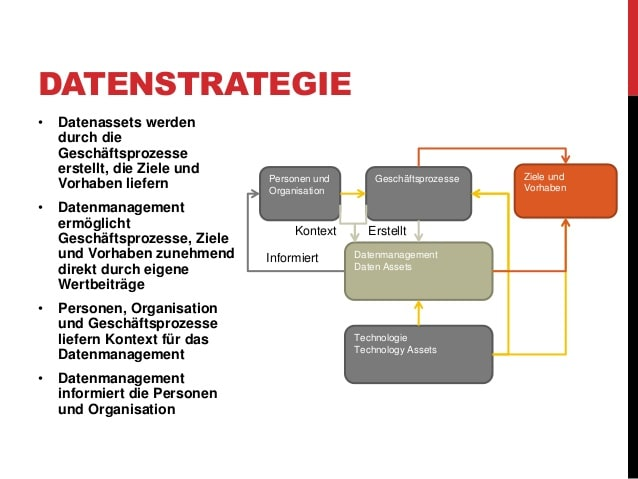

Abb. 3.b.1: Datenstrategie

### 3.c) Prozesse des Data Mining

#### Definition Data Mining

**Data Mining** ist ein analytischer Prozess, der eine möglichst autonome und effiziente Identifizierung und Beschreibung von **interessanten Datenmustern** aus großen Datenbeständen ermöglicht.

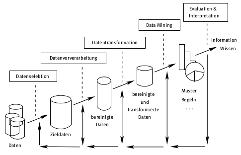

Abb. 3.c.1: *Ablauf eines Data-Mining-Prozesses*

#### Methoden

Die **Methoden** des Data Minings lassen sich grundsätzlich in die Gruppen **Klassifikation**, **Prognose**, **Segmentierung** und **Abhängigkeits- entdeckung** enteilen.

### 3.d) Techniken des Data Mining

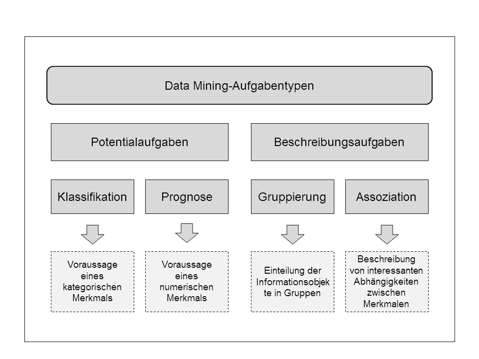

Abb. 3.d.1: Data Mining Aufgabetypen

#### Grundsätzliches

Die **Visualisierung** von Datenanalyse Ergebnissen reicht in der Regel alleine nicht aus. Bei der vorherigen **Datentransformation** mittels die **Schlüsselverben** werden wichtige **Variablen** ausgewählt und die wichtigen **Beobachtungen** herausgefiltert. Zudem können neue Variablen erstellt, sowie sinnvolle **Zusammenfassungen** berechnet werden (Wickham & Grolemund, 2017).

### 3.e) Visuelle und Maschinelle Verfahren des Data Mining

#### Visuelle Verfahren

Unter zur Hilfename von Tools, können **Data Mining Prozesse** und **Algorithmen** einfach konfiguriert und die Ergebnisse zur leichten Verständlichkeit visualisiert werden.

Ein Beispiel ist *Knime.* Die Datenmanipulation wird visuell anhand einzelner **Funktionsknoten** dargestellt und kann individuell beschriftet werden. Dadurch werden die einzelnen Prozessschritte greifbar und der komplette Analyseprozess dadurch langfristig **nachvollziehbar** und **reproduzierbar**.

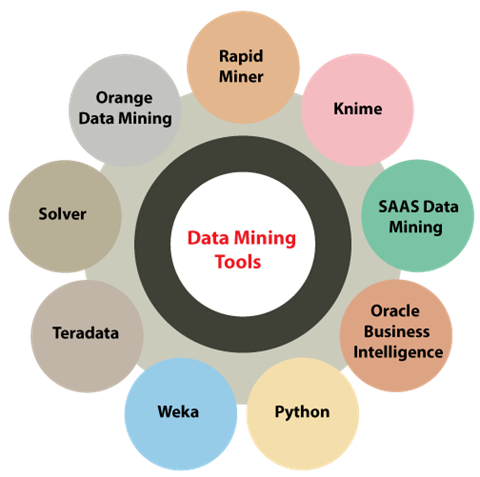

Abb. 3.e.1: Data Mining Tools

**Maschinelle Verfahren** (Datei *mining.py* auf Ilias)

Mittels **Programmierung** (oder Scripting) ist es möglich Datenauswertungen durch die Ausführung von Code zu erstellen. Für die Datenanalyse wird am häufigsten die Programmiersprache *Python* verwendet.

```python
# Bibliotheken laden
import pandas as pd
import matplotlib.pyplot as plt
import numpy as np
import scipy.stats as stats
import seaborn as sns
from matplotlib import rcParams

# Daten sichten
# read data from csv file
df = pd.read_csv('./Daten/kc_house_data.csv')
print(df.describe())
```

#### Die Algorithmen

Zur Mustererkennung in Daten kommen **Algorithmen** aus der **Statistik**, **Mathematik** und Informatik zum Einsatz.

### 3.f) Einführung und Übersicht der Algorithmen des Data Mining

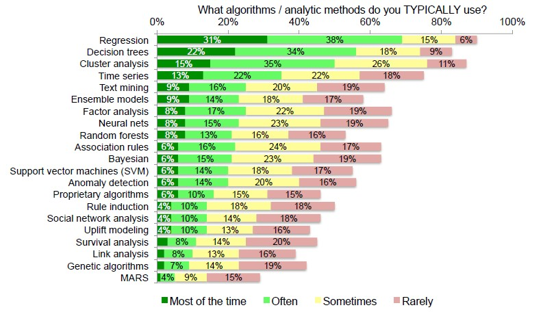

Abb. 3.e.1: Data Mining Algorithmen in der Häufigkeit der Anwendung

#### Anwendungsbeispiele

- **Customer Relationship Management**
  - CLV-Vorhersagen
  - Cross- und Upselling Optimierung
  - Churn Prediction
- **Produktion und Logistik**
  - Optimierung der Supply Chain
  - Predictive Maintenance
  - Prognose von Nachfrage
- **Medizin / Forschung Allgemein**
  - Erkennung von Krankheiten auf Bildern
  - Therapievorschläge
  - Identifizierung von Anomalien